# Wine Quality Exploration by Katerina Baneva

# Introduction

This project investigates the relationship between the ranking of red and white wines quality by human experts and 11 variables resulting from physicochemical tests carried out against the wines.

Citation: This dataset is public available for research. The details are described in [Cortez et al., 2009]. P. Cortez, A. Cerdeira, F. Almeida, T. Matos and J. Reis. Modeling wine preferences by data mining from physicochemical properties. In Decision Support Systems, Elsevier, 47(4):547-553. ISSN: 0167-9236.The link to the red wine dateset can be find [here](https://www.google.com/url?q=https://s3.amazonaws.com/udacity-hosted-downloads/ud651/wineQualityReds.csv&sa=D&usg=AFQjCNFDGQM6iS1viDgkVnXfjlJUymYerA) and for white wine [here](https://www.google.com/url?q=https://s3.amazonaws.com/udacity-hosted-downloads/ud651/wineQualityWhites.csv&sa=D&usg=AFQjCNHSo6vCJWIjCOZw6Kyy-C79XNFQUg). Read this [text file](https://www.google.com/url?q=https://s3.amazonaws.com/udacity-hosted-downloads/ud651/wineQualityInfo.txt&sa=D&usg=AFQjCNFCYPcMpGaIuxge2KbBPILOo5yPZA) which describes the variables and how the data was collected.

The issue of quality has become increasingly important to the wine industry over the past several decades. Worldwide, an oversupply situation has prevailed, consequently pulling down wine prices and decreasing profitable margins for producers. It has been suggested that the wine industry must vigilantly attend to wine quality, in conjunction to marketing efforts in order to lead the competition. This raises important question as to what is meant by quality regarding wine. Quality may be understood in different ways. Generally, quality in foods and beverages is defined as the ability of a set of inherent characteristics of a product, system or process to fulfill requirements of customers and other interested parties. From the perspective of marketing, with reference to wine, there exist two quality dimensions based on the consumer experiences: the external (grapes, production and marketing) and the internal (pleasure, appearance, gustatory, paradigmatic and potential) quality, the latter being more significant in evaluating the overall wine quality during consumption. However, some marketing studies have defined the concept of quality as a one-dimensional judgment.Perceived quality is a broad overview and exists on a continuum.

## Variables

Input variables (based on physicochemical tests):

- fixed acidity (tartaric acid - g / dm^3)
- volatile acidity (acetic acid - g / dm^3)
- citric acid (g / dm^3)
- residual sugar (g / dm^3)
- chlorides (sodium chloride - g / dm^3
- free sulfur dioxide (mg / dm^3)
- total sulfur dioxide (mg / dm^3)
- density (g / cm^3)
- pH
- sulphates (potassium sulphate - g / dm3)
- alcohol (% by volume)

### Output

The output variable is the quality(based on sensory data) ranking. This is an integer in the range 0 (very bad) to 10 (very excellent).

I decided to explore the white wines and red wines dataset. Therefore i merged them into one dataframe caled wine.

```
## [1] 6497   13
```

```
##  [1] "fixed.acidity"        "volatile.acidity"     "citric.acid"
##  [4] "residual.sugar"       "chlorides"            "free.sulfur.dioxide"
##  [7] "total.sulfur.dioxide" "density"              "pH"
## [10] "sulphates"            "alcohol"              "quality"
## [13] "color"
```

```
## 'data.frame':    6497 obs. of  13 variables:
##  $ fixed.acidity       : num  7.4 7.8 7.8 11.2 7.4 7.4 7.9 7.3 7.8 7.5 ...
##  $ volatile.acidity    : num  0.7 0.88 0.76 0.28 0.7 0.66 0.6 0.65 0.58 0.5 ...
##  $ citric.acid         : num  0 0 0.04 0.56 0 0 0.06 0 0.02 0.36 ...
##  $ residual.sugar      : num  1.9 2.6 2.3 1.9 1.9 1.8 1.6 1.2 2 6.1 ...
##  $ chlorides           : num  0.076 0.098 0.092 0.075 0.076 0.075 0.069 0.065 0.073 0.071 ...
##  $ free.sulfur.dioxide : num  11 25 15 17 11 13 15 15 9 17 ...
##  $ total.sulfur.dioxide: num  34 67 54 60 34 40 59 21 18 102 ...
##  $ density             : num  0.998 0.997 0.997 0.998 0.998 ...
##  $ pH                  : num  3.51 3.2 3.26 3.16 3.51 3.51 3.3 3.39 3.36 3.35 ...
##  $ sulphates           : num  0.56 0.68 0.65 0.58 0.56 0.56 0.46 0.47 0.57 0.8 ...
##  $ alcohol             : num  9.4 9.8 9.8 9.8 9.4 9.4 9.4 10 9.5 10.5 ...
##  $ quality             : int  5 5 5 6 5 5 5 7 7 5 ...
##  $ color               : chr  "red" "red" "red" "red" ...
```

```
##  fixed.acidity    volatile.acidity  citric.acid     residual.sugar
##  Min.   : 3.800   Min.   :0.0800   Min.   :0.0000   Min.   : 0.600
##  1st Qu.: 6.400   1st Qu.:0.2300   1st Qu.:0.2500   1st Qu.: 1.800
##  Median : 7.000   Median :0.2900   Median :0.3100   Median : 3.000
##  Mean   : 7.215   Mean   :0.3397   Mean   :0.3186   Mean   : 5.443
##  3rd Qu.: 7.700   3rd Qu.:0.4000   3rd Qu.:0.3900   3rd Qu.: 8.100
##  Max.   :15.900   Max.   :1.5800   Max.   :1.6600   Max.   :65.800
##    chlorides       free.sulfur.dioxide total.sulfur.dioxide
##  Min.   :0.00900   Min.   :  1.00      Min.   :  6.0
##  1st Qu.:0.03800   1st Qu.: 17.00      1st Qu.: 77.0
##  Median :0.04700   Median : 29.00      Median :118.0
##  Mean   :0.05603   Mean   : 30.53      Mean   :115.7
##  3rd Qu.:0.06500   3rd Qu.: 41.00      3rd Qu.:156.0
##  Max.   :0.61100   Max.   :289.00      Max.   :440.0
##     density             pH          sulphates         alcohol
##  Min.   :0.9871   Min.   :2.720   Min.   :0.2200   Min.   : 8.00
##  1st Qu.:0.9923   1st Qu.:3.110   1st Qu.:0.4300   1st Qu.: 9.50
##  Median :0.9949   Median :3.210   Median :0.5100   Median :10.30
##  Mean   :0.9947   Mean   :3.219   Mean   :0.5313   Mean   :10.49
##  3rd Qu.:0.9970   3rd Qu.:3.320   3rd Qu.:0.6000   3rd Qu.:11.30
##  Max.   :1.0390   Max.   :4.010   Max.   :2.0000   Max.   :14.90
##     quality         color
##  Min.   :3.000   Length:6497
##  1st Qu.:5.000   Class :character
##  Median :6.000   Mode  :character
##  Mean   :5.818
##  3rd Qu.:6.000
##  Max.   :9.000
```

```
##   fixed.acidity volatile.acidity citric.acid residual.sugar chlorides
## 1           7.4             0.70        0.00            1.9     0.076
## 2           7.8             0.88        0.00            2.6     0.098
## 3           7.8             0.76        0.04            2.3     0.092
## 4          11.2             0.28        0.56            1.9     0.075
## 5           7.4             0.70        0.00            1.9     0.076
## 6           7.4             0.66        0.00            1.8     0.075
##   free.sulfur.dioxide total.sulfur.dioxide density   pH sulphates alcohol
## 1                  11                   34  0.9978 3.51      0.56     9.4
## 2                  25                   67  0.9968 3.20      0.68     9.8
## 3                  15                   54  0.9970 3.26      0.65     9.8
## 4                  17                   60  0.9980 3.16      0.58     9.8
## 5                  11                   34  0.9978 3.51      0.56     9.4
## 6                  13                   40  0.9978 3.51      0.56     9.4
##   quality color
## 1       5   red
## 2       5   red
## 3       5   red
## 4       6   red
## 5       5   red
## 6       5   red
```

```
##      fixed.acidity volatile.acidity citric.acid residual.sugar chlorides
## 6492           6.5             0.23        0.38            1.3     0.032
## 6493           6.2             0.21        0.29            1.6     0.039
## 6494           6.6             0.32        0.36            8.0     0.047
## 6495           6.5             0.24        0.19            1.2     0.041
## 6496           5.5             0.29        0.30            1.1     0.022
## 6497           6.0             0.21        0.38            0.8     0.020
##      free.sulfur.dioxide total.sulfur.dioxide density   pH sulphates
## 6492                  29                  112 0.99298 3.29      0.54
## 6493                  24                   92 0.99114 3.27      0.50
## 6494                  57                  168 0.99490 3.15      0.46
## 6495                  30                  111 0.99254 2.99      0.46
## 6496                  20                  110 0.98869 3.34      0.38
## 6497                  22                   98 0.98941 3.26      0.32
##      alcohol quality color
## 6492     9.7       5 white
## 6493    11.2       6 white
## 6494     9.6       5 white
## 6495     9.4       6 white
## 6496    12.8       7 white
## 6497    11.8       6 white
```

Examining the quality variable.

```
##
##    3    4    5    6    7    8    9
##   30  216 2138 2836 1079  193    5
```

- I added new categorical variale color and removed the X variable.
- There are 13 variables and 6497 observations in the wine dataset.
- The variables free.sulfur.dioxide and total.sulfur.dioxide are discrete
- The quality variable range is between 3 and 9, no extreme values. The scale for quality normally is between 0-10 with 0 the lowest and 10 the highest. The median is 6 and the mean is equal to 5.8.
- The rest of the variables are continuous.

# Univariate Plots and Analysis Section

The plots below depict the distribution of all the variables in the dateset separated by the color of the wine. Since there are 1599 observations for the red wine and 4898 for the white I plotted the normalized data as well.

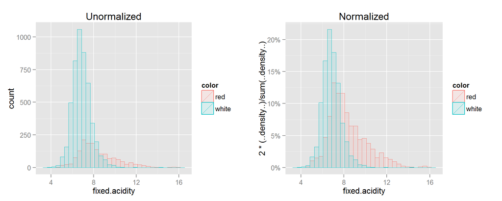

The distribution appears to be a little right skewed for the red wine and normal for the white. Red wine has higher level of fixed acidity. Those are nonvolatile which means that they do not evaporate or boil off when the wine is heated.

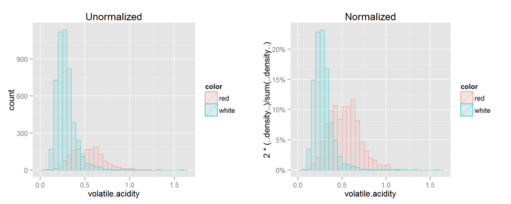

The distribution of the white wine looks highly right skewed compared to that of the red wine.Also, white wine is lower on volatile acids. Volatile acidity (VA) in wine represents acetic acid (vinegar). Acetic acid does boil off when heated, and high VA is undesirable in a wine. A VA of 0.03-0.06% is produced during fermentation and is considered a normal level. In the plots we see high levels of VA.

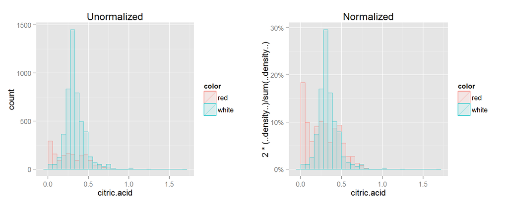

In the red wine there are a lot of observations with citric acid equal to zero.The distribution for the red wine is right skewed again, normal distribution for white wine but with few outliers.

```
##    Min. 1st Qu.  Median    Mean 3rd Qu.    Max.
##   0.600   1.800   3.000   5.443   8.100  65.800
```

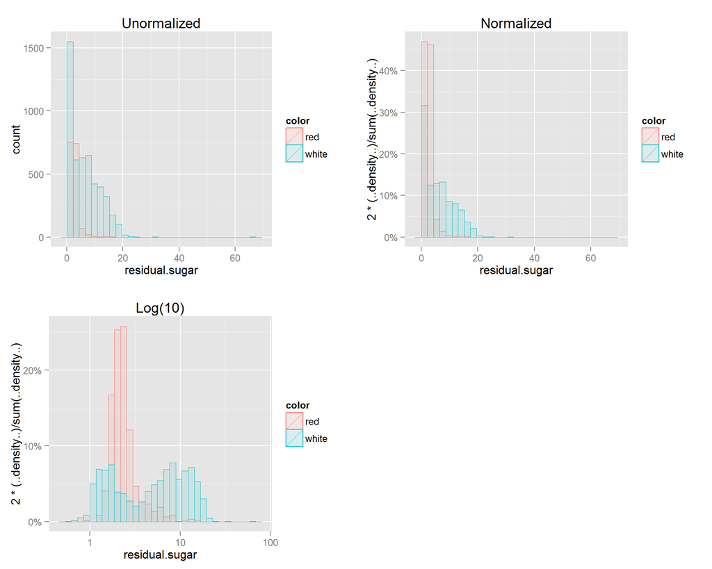

Highly right skewed distributions for both wines. From the summary statistc we see that there is probably an outlier since the max values is equal to 65.800 and there is a difference between the mean and the median. So i added a log plot as well. Surprisongly we can see that the distribution for the white wines is bimodal.

```
##    Min. 1st Qu.  Median    Mean 3rd Qu.    Max.
## 0.00900 0.03800 0.04700 0.05603 0.06500 0.61100
```

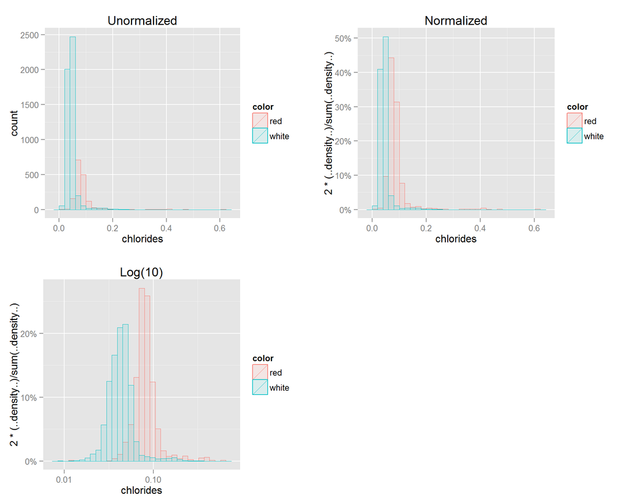

Right skewed distributions with long tails for both wines. More chlorides are present in the red wine.From the summary statistic we can see that there is probably an outlier.So i added a log plot here too.

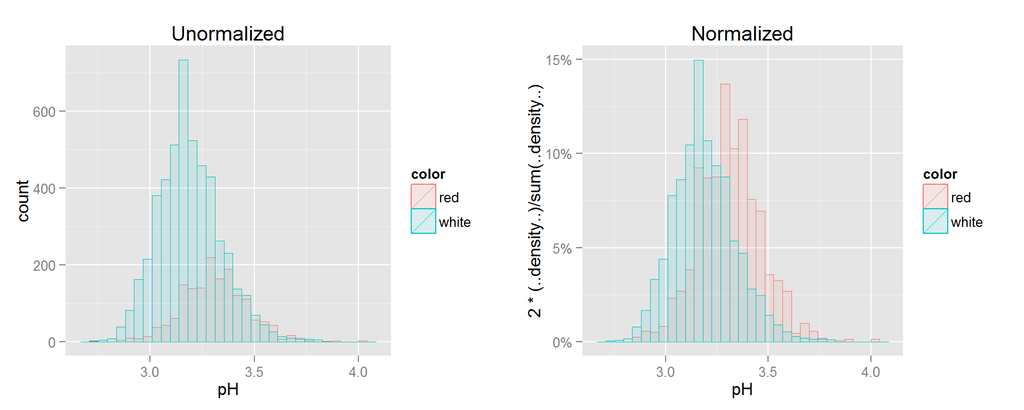

Normal distributions for both wines.The measurement of pH is the number of H+ ions in a solution using a logarithmic scale, with a lower number denoting a higher concentration of H+ ions. Translation: the difference between a wine with a pH of 4.0 and with a pH of 3.0 is that the wine with the pH of 3.0 has 10x the number of hydrogen ions as the pH 4.0 wine (or 1x10-3 versus 1x10-4 H+ ions).

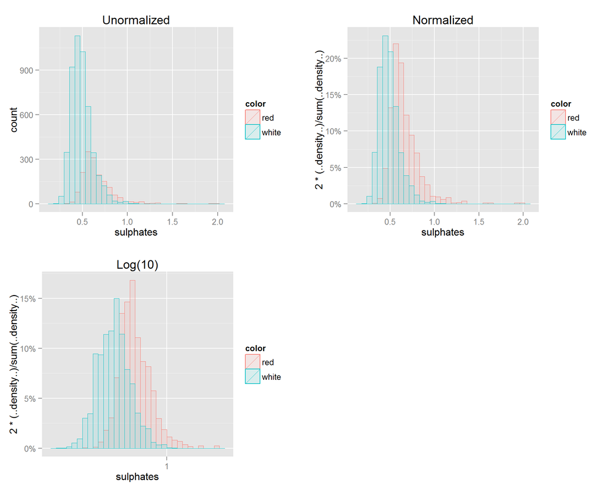

Right skewed distribution with outliers for both wines.Red wine has higher level of sulphates.

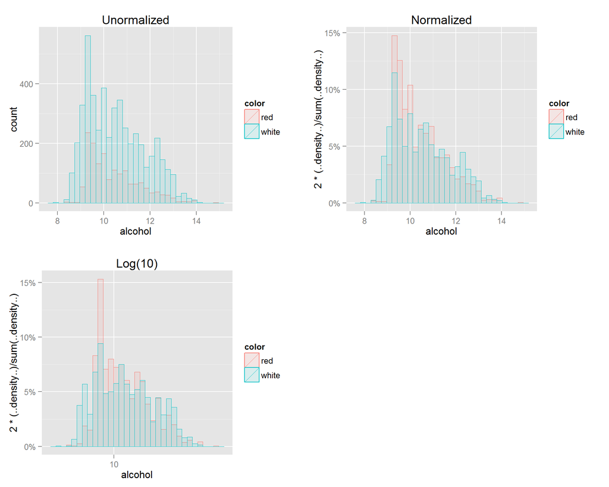

Right skewed distribution.There wasn’t much change when i used the log transformation.

```
##    Min. 1st Qu.  Median    Mean 3rd Qu.    Max.
##  0.9871  0.9923  0.9949  0.9947  0.9970  1.0390
```

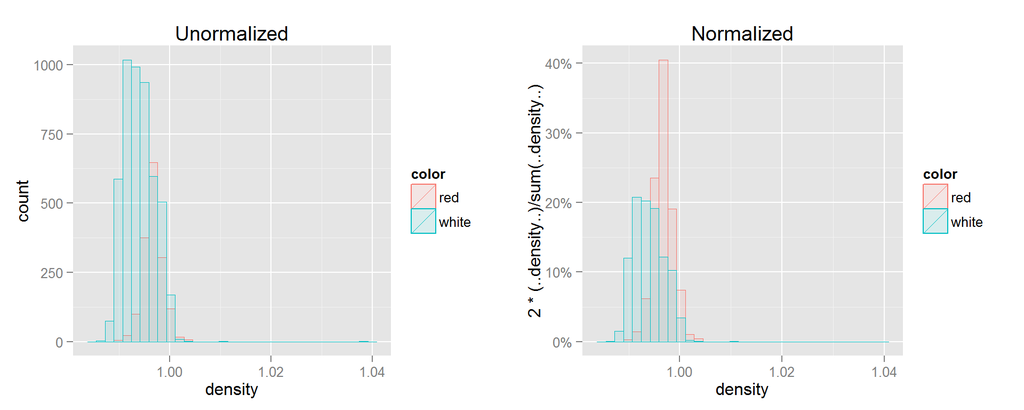

Normal distribution for both wines.it looks like red wine has higher density.

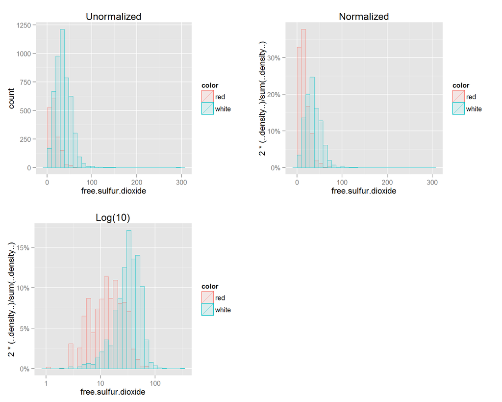

Right skewed distribution for both wines.Most of the red wines have less free sulfur dioxide than the white wines.

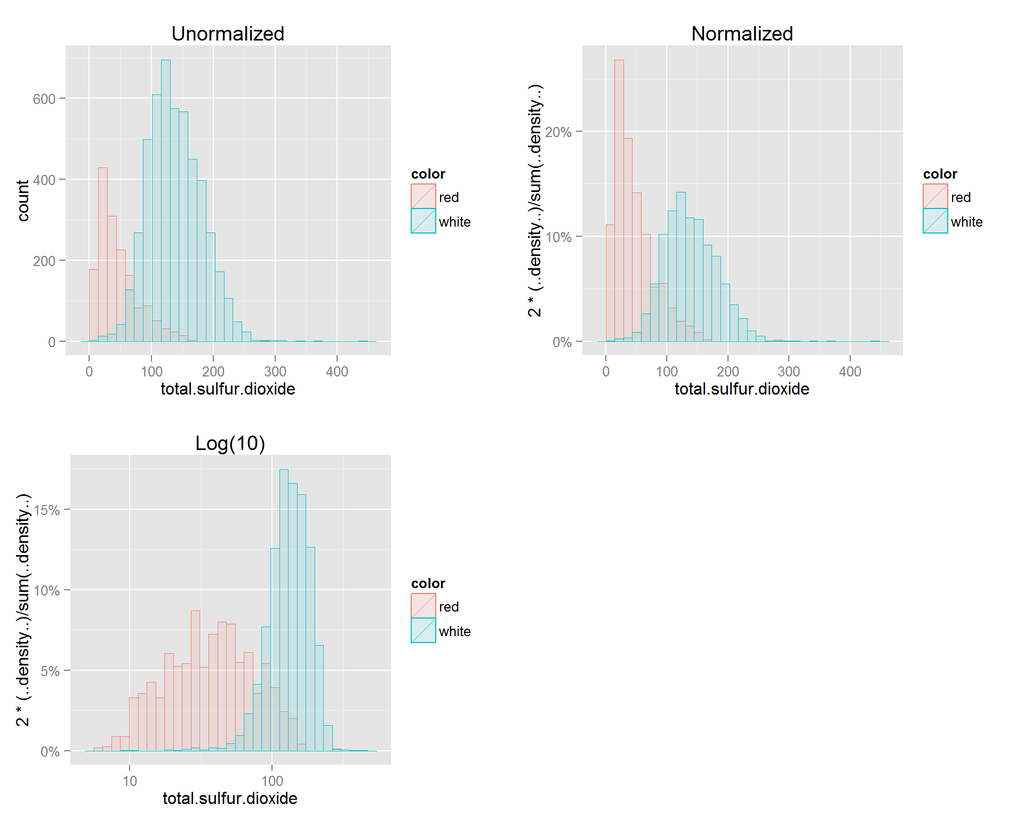

Right skewed distribution for red wine and approximately normal distribution for white wine.We see here that red wine has less total sulfur dioxide than the white wine as well.

[figure not shown]

Normal distribution. Most of the wines are ranked between 5 and 6 for both types of the beverages.

```
##    Min. 1st Qu.  Median    Mean 3rd Qu.    Max.
##   4.130   7.020   7.600   7.874   8.380  17.050
```

```
##    Min. 1st Qu.  Median    Mean 3rd Qu.    Max.
##   3.800   6.400   7.000   7.215   7.700  15.900
```

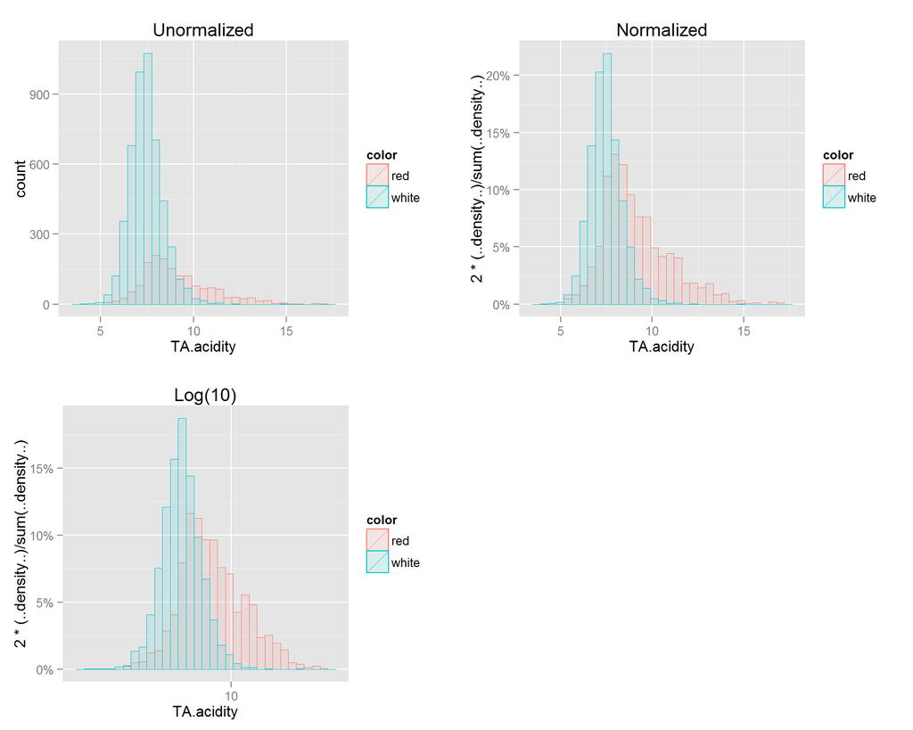

I decided to combine all the three acids in the dataset into one called TA, since that is a widely used measurement for determining wine types.

# Bivariate Plots and Analysis Section

In order to get a quick sense of how the variables affect quality of red and white wines I plotted the following boxplot.

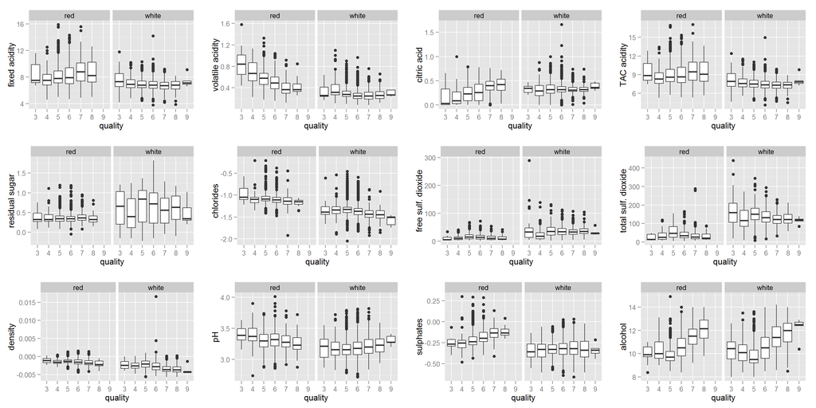

Red and white wines have different behaviours.For example: + volatile acidity appears to have go down with quality gowing up for red wines + citric acid goes up with quality levels rising for red wines + residual sugar has a wide IQR for white wines, as we saw the distribution there was bimodal + white wines have higher values of total sulfur dioxide compared to red ones + looking at density we can not say anithing about it for now, but I will investigate it later since I believe it is important for quality + the level of sulphates increase as the quality does for red wines + with the levels of alcohol rising the quility rises

```
## Source: local data frame [6 x 4]
##
##   quality color mean_volatile.acidity     n
##     (int) (chr)                 (dbl) (int)
## 1       3   red             0.8845000    10
## 2       3 white             0.3332500    20
## 3       4   red             0.6939623    53
## 4       4 white             0.3812270   163
## 5       5   red             0.5770411   681
## 6       5 white             0.3020110  1457
```

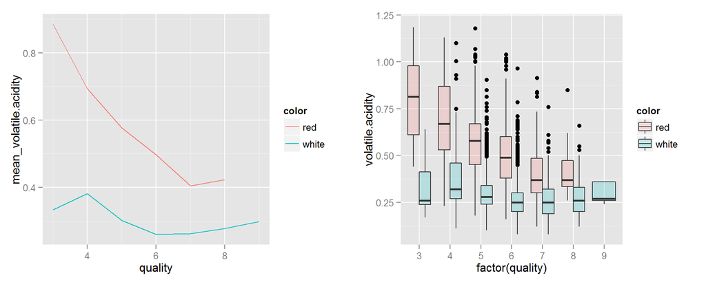

```
##
##  Pearson's product-moment correlation
##
## data:  volatile.acidity and quality
## t = -13.891, df = 4896, p-value < 2.2e-16
## alternative hypothesis: true correlation is not equal to 0
## 95 percent confidence interval:
##  -0.2215214 -0.1676307
## sample estimates:
##       cor
## -0.194723
```

```
##
##  Pearson's product-moment correlation
##
## data:  volatile.acidity and quality
## t = -16.954, df = 1597, p-value < 2.2e-16
## alternative hypothesis: true correlation is not equal to 0
## 95 percent confidence interval:
##  -0.4313210 -0.3482032
## sample estimates:
##        cor
## -0.3905578
```

The graph confirmed my what the boxplot showed above.Low quality red wine has higher average leves of volatile acidity and the correlation is - 0.39. White wine on the other hand has lower average volatile acidity across all qualities.

```
## Source: local data frame [6 x 4]
##
##   quality color mean_citric.acid     n
##     (int) (chr)            (dbl) (int)
## 1       3   red        0.1710000    10
## 2       3 white        0.3360000    20
## 3       4   red        0.1741509    53
## 4       4 white        0.3042331   163
## 5       5   red        0.2436858   681
## 6       5 white        0.3376527  1457
```

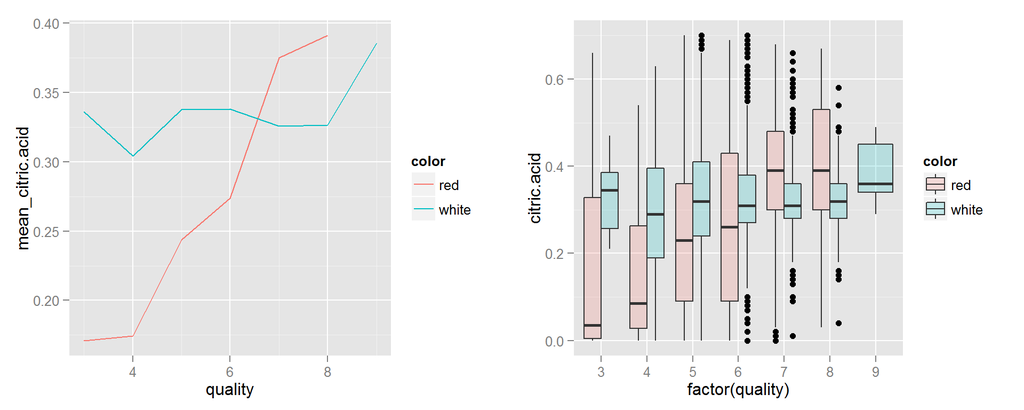

```
##
##  Pearson's product-moment correlation
##
## data:  citric.acid and quality
## t = -0.6444, df = 4896, p-value = 0.5193
## alternative hypothesis: true correlation is not equal to 0
## 95 percent confidence interval:
##  -0.03720595  0.01880221
## sample estimates:
##          cor
## -0.009209091
```

```
##
##  Pearson's product-moment correlation
##
## data:  citric.acid and quality
## t = 9.2875, df = 1597, p-value < 2.2e-16
## alternative hypothesis: true correlation is not equal to 0
## 95 percent confidence interval:
##  0.1793415 0.2723711
## sample estimates:
##       cor
## 0.2263725
```

Very interesting relationship between quality and citric acid for red wine. The average citric acid is going up parallel with quality. White wine’s quality doesn’t seem to be affected by the citric acid.

```
## Source: local data frame [6 x 4]
##
##   quality color mean_res.sugar     n
##     (int) (chr)          (dbl) (int)
## 1       3   red       2.635000    10
## 2       3 white       6.392500    20
## 3       4   red       2.694340    53
## 4       4 white       4.628221   163
## 5       5   red       2.528855   681
## 6       5 white       7.334969  1457
```

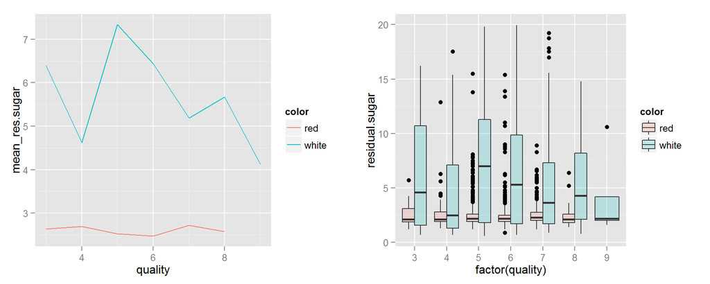

```
## [1] -0.06463176
```

```
## [1] 0.02353331
```

Both correlations are very low. Red wine has much lower residual sugar on average conpared to white one.

```
## Source: local data frame [6 x 4]
##
##   quality color mean_total_sd     n
##     (int) (chr)         (dbl) (int)
## 1       3   red      24.90000    10
## 2       3 white     170.60000    20
## 3       4   red      36.24528    53
## 4       4 white     125.27914   163
## 5       5   red      56.51395   681
## 6       5 white     150.90460  1457
```

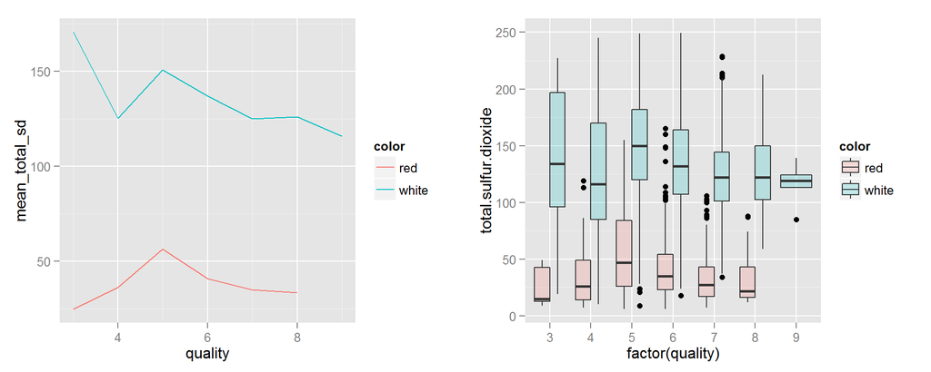

```
##
##  Pearson's product-moment correlation
##
## data:  total.sulfur.dioxide and quality
## t = -12.418, df = 4896, p-value < 2.2e-16
## alternative hypothesis: true correlation is not equal to 0
## 95 percent confidence interval:
##  -0.2017563 -0.1474524
## sample estimates:
##        cor
## -0.1747372
```

```
##
##  Pearson's product-moment correlation
##
## data:  total.sulfur.dioxide and quality
## t = -7.5271, df = 1597, p-value = 8.622e-14
## alternative hypothesis: true correlation is not equal to 0
## 95 percent confidence interval:
##  -0.2320162 -0.1373252
## sample estimates:
##        cor
## -0.1851003
```

Apart from that the red wine has lower average levels of totals sulfur dioxide than white wine, I don’t see any other connection. Also, the correlations are too low.

```
## Source: local data frame [6 x 4]
##
##   quality color mean_density     n
##     (int) (chr)        (dbl) (int)
## 1       3   red    0.9974640    10
## 2       3 white    0.9948840    20
## 3       4   red    0.9965425    53
## 4       4 white    0.9942767   163
## 5       5   red    0.9971036   681
## 6       5 white    0.9952626  1457
```

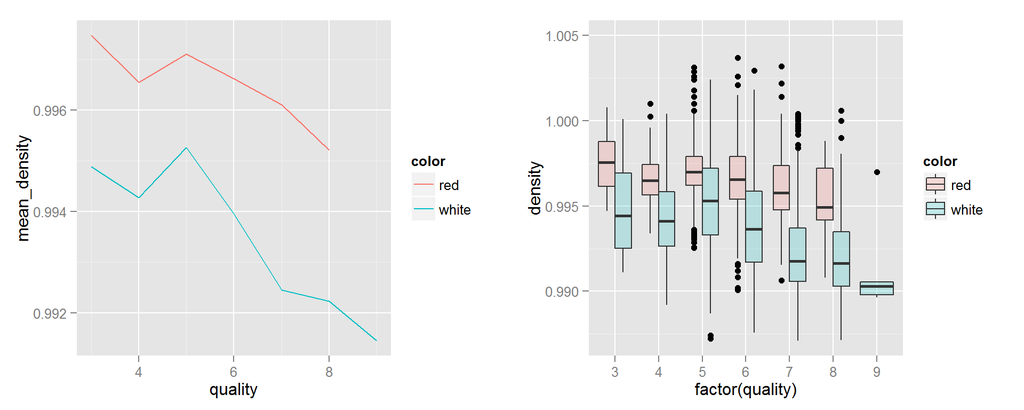

```
## [1] -0.3071233
```

```
## [1] -0.1749192
```

The correlation for white wine is higher than for red wine.We see also from the graph that quality and density have negative correlation.

```
## Source: local data frame [6 x 4]
##
##   quality color mean_sulphates     n
##     (int) (chr)          (dbl) (int)
## 1       3   red      0.5700000    10
## 2       3 white      0.4745000    20
## 3       4   red      0.5964151    53
## 4       4 white      0.4761350   163
## 5       5   red      0.6209692   681
## 6       5 white      0.4822032  1457
```

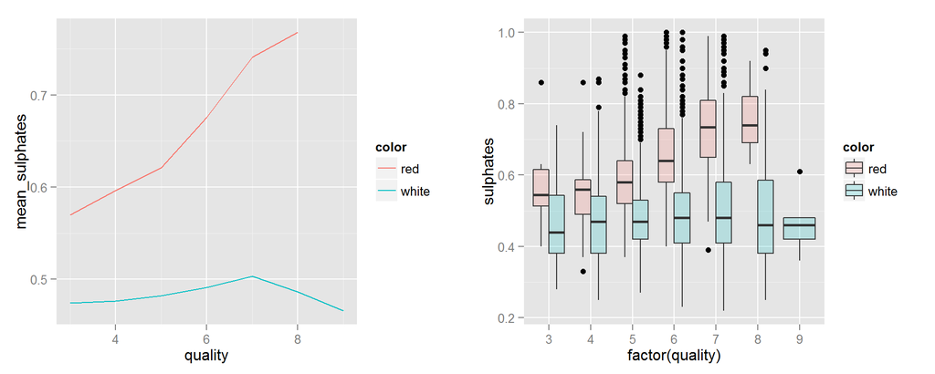

```
## [1] 0.05367788
```

```
## [1] 0.2513971
```

```
## Source: local data frame [6 x 4]
##
##   quality color mean_alcohol     n
##     (int) (chr)        (dbl) (int)
## 1       3   red     9.955000    10
## 2       3 white    10.345000    20
## 3       4   red    10.265094    53
## 4       4 white    10.152454   163
## 5       5   red     9.899706   681
## 6       5 white     9.808840  1457
```

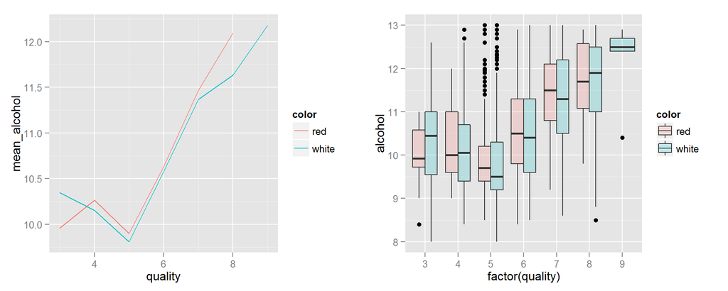

```
##
##  Pearson's product-moment correlation
##
## data:  alcohol and quality
## t = 33.858, df = 4896, p-value < 2.2e-16
## alternative hypothesis: true correlation is not equal to 0
## 95 percent confidence interval:
##  0.4126015 0.4579941
## sample estimates:
##       cor
## 0.4355747
```

```
##
##  Pearson's product-moment correlation
##
## data:  alcohol and quality
## t = 21.639, df = 1597, p-value < 2.2e-16
## alternative hypothesis: true correlation is not equal to 0
## 95 percent confidence interval:
##  0.4373540 0.5132081
## sample estimates:
##       cor
## 0.4761663
```

There is an obvious correlation between quality and alcohol that we can see from the graph and from the correalation test. That is the strongest relationship between a feature and quality.

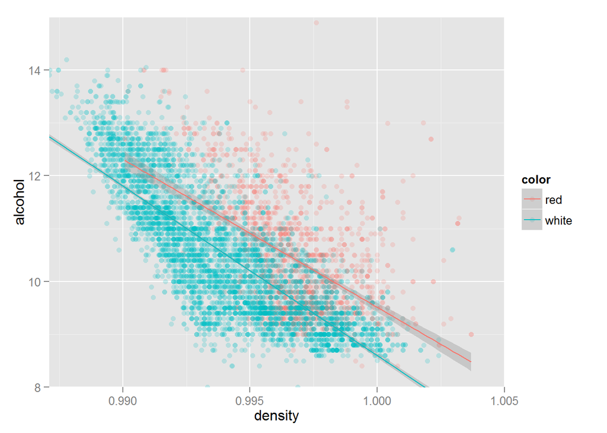

```
##
##  Pearson's product-moment correlation
##
## data:  alcohol and density
## t = -87.255, df = 4896, p-value < 2.2e-16
## alternative hypothesis: true correlation is not equal to 0
## 95 percent confidence interval:
##  -0.7908646 -0.7689315
## sample estimates:
##        cor
## -0.7801376
```

```
##
##  Pearson's product-moment correlation
##
## data:  alcohol and density
## t = -22.838, df = 1597, p-value < 2.2e-16
## alternative hypothesis: true correlation is not equal to 0
## 95 percent confidence interval:
##  -0.5322547 -0.4583061
## sample estimates:
##        cor
## -0.4961798
```

Alcohol and density have strong negative correlation.The density depends on the levels of alcohol.

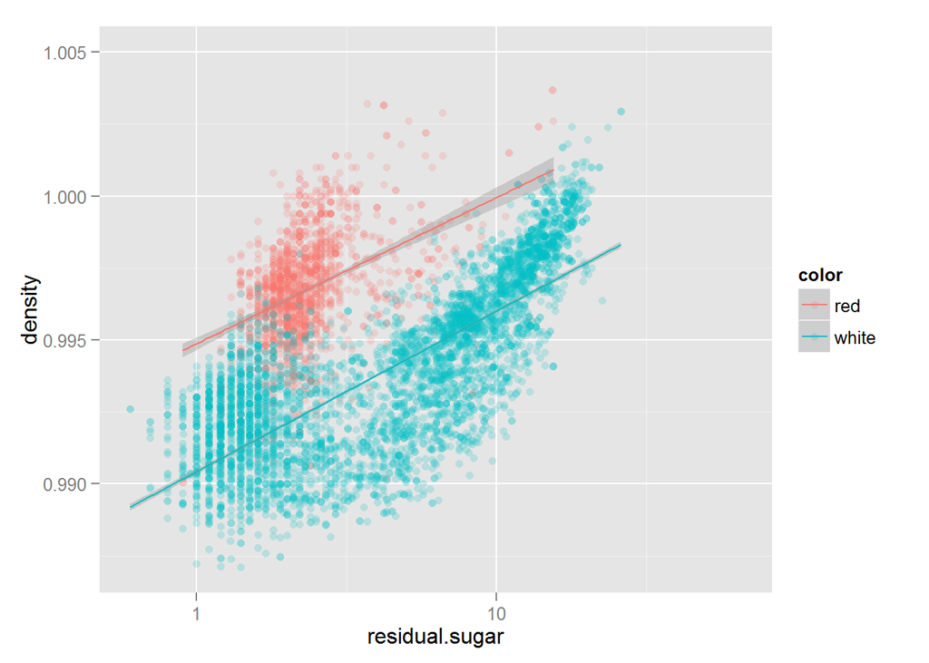

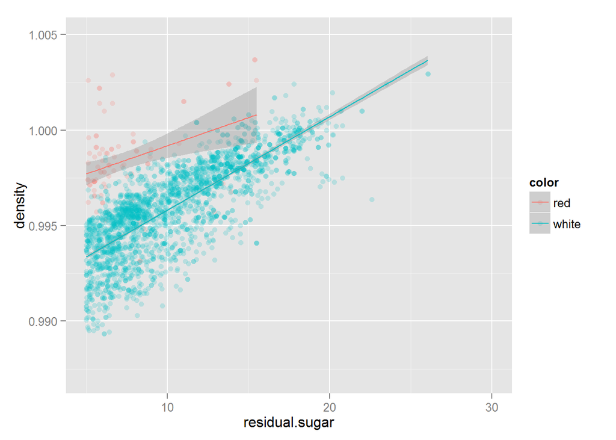

```
##
##  Pearson's product-moment correlation
##
## data:  residual.sugar and density
## t = 67.336, df = 2486, p-value < 2.2e-16
## alternative hypothesis: true correlation is not equal to 0
## 95 percent confidence interval:
##  0.7892954 0.8171552
## sample estimates:
##       cor
## 0.8036652
```

```
##
##  Pearson's product-moment correlation
##
## data:  residual.sugar and density
## t = 3.3101, df = 82, p-value = 0.001388
## alternative hypothesis: true correlation is not equal to 0
## 95 percent confidence interval:
##  0.1391688 0.5194786
## sample estimates:
##       cor
## 0.3433203
```

There is evident correaltion between residual sugar and density, since sugar affects the density of the wine.Furthermore, the correlation is very high for the white wines equal to 0.80.

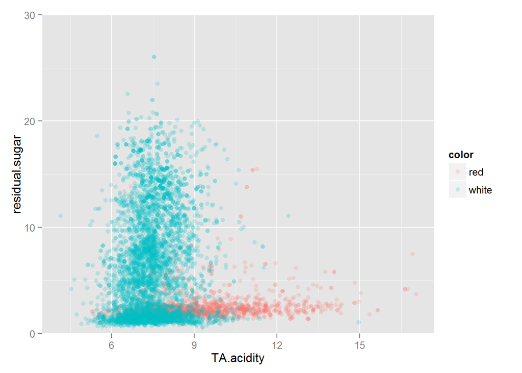

```
##
##  Pearson's product-moment correlation
##
## data:  residual.sugar and TA.acidity
## t = 6.0192, df = 2486, p-value = 2.012e-09
## alternative hypothesis: true correlation is not equal to 0
## 95 percent confidence interval:
##  0.08093696 0.15840402
## sample estimates:
##       cor
## 0.1198529
```

```
##
##  Pearson's product-moment correlation
##
## data:  residual.sugar and TA.acidity
## t = 0.3281, df = 82, p-value = 0.7437
## alternative hypothesis: true correlation is not equal to 0
## 95 percent confidence interval:
##  -0.179580  0.248674
## sample estimates:
##        cor
## 0.03620927
```

Very low correlation, which is not what I have expected. High level of residual sugar balanced with aditioanal acidity equals high quality, for example. We will see later if that affects quality.

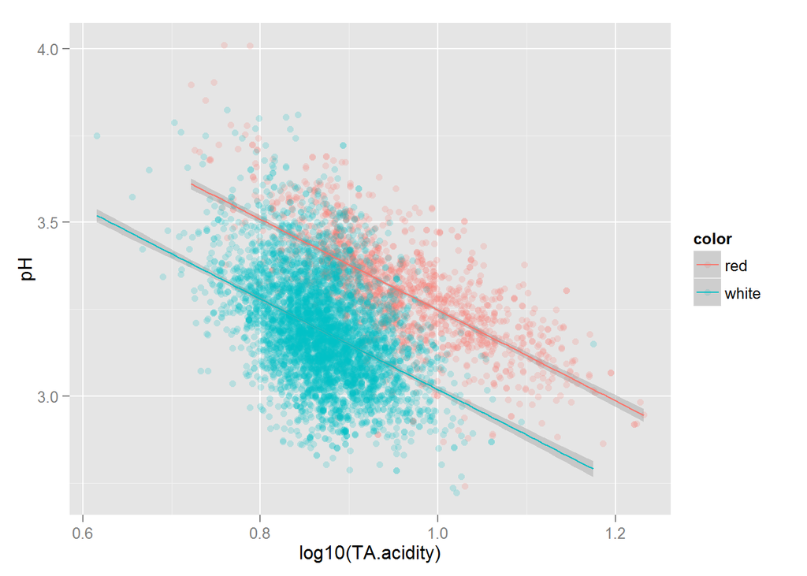

```
##
##  Pearson's product-moment correlation
##
## data:  pH and log10(TA.acidity)
## t = -34.256, df = 4896, p-value < 2.2e-16
## alternative hypothesis: true correlation is not equal to 0
## 95 percent confidence interval:
##  -0.4620204 -0.4168302
## sample estimates:
##        cor
## -0.4397036
```

```
##
##  Pearson's product-moment correlation
##
## data:  pH and log10(TA.acidity)
## t = -39.663, df = 1597, p-value < 2.2e-16
## alternative hypothesis: true correlation is not equal to 0
## 95 percent confidence interval:
##  -0.7283140 -0.6788653
## sample estimates:
##        cor
## -0.7044435
```

High negative correlation between those two variables, especially in red wines. While one may think that TA and pH are directly correlated as acidity indicators, they are not.The measurement of pH is the number of H+ ions in a solution using a logarithmic scale, with a lower number denoting a higher concentration of H+ ions. Translation: the difference between a wine with a pH of 4.0 and with a pH of 3.0 is that the wine with the pH of 3.0 has 10x the number of hydrogen ions as the pH 4.0 wine (or 1x10-3 versus 1x10-4 H+ ions). The measurement of acidic content is the acid’s potential to liberate H+ ions as it dissociates. While acid content affects pH, it is not directly predictive of pH (or vice versa). This non-direct correlation is partially due to pH “buffering” caused by a number of compounds in wines, such as sugars, acids, and phenolic compounds. Buffering occurs because these compounds exist in equilibrium between their acid and conjugate base forms; the ratio of the two forms to one another must be significantly shifted before a noticeable pH change can occur. Just as pH calibration buffer solutions effectively calibrate pH equipment due to their reliable stability, the addition of a given amount of acid to a wine may not reduce the pH as expected due to the wine’s buffering capacity to maintain a stable pH. .

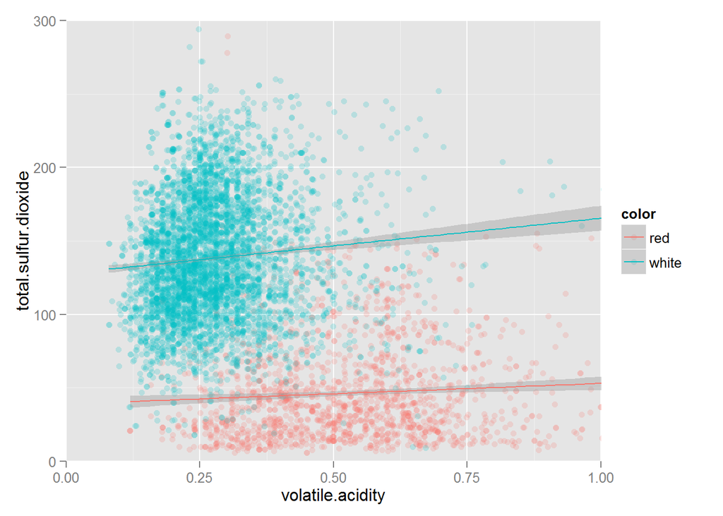

```
##
##  Pearson's product-moment correlation
##
## data:  volatile.acidity and total.sulfur.dioxide
## t = 6.2707, df = 4896, p-value = 3.903e-10
## alternative hypothesis: true correlation is not equal to 0
## 95 percent confidence interval:
##  0.06140756 0.11697454
## sample estimates:
##       cor
## 0.0892605
```

```
##
##  Pearson's product-moment correlation
##
## data:  volatile.acidity and total.sulfur.dioxide
## t = 3.0649, df = 1597, p-value = 0.002214
## alternative hypothesis: true correlation is not equal to 0
## 95 percent confidence interval:
##  0.02755215 0.12502248
## sample estimates:
##     cor
## 0.07647
```

Volatile acidity is responcible for vineger taste, and tatal sulfur dioxide in higher quantities becomes evident in the taste and nose.Those two variables can affect the perception of quality. I am curious how those both variables affect the quality of the wine.We se that the correlation between them is very low.

# Multivariate Plots and Analysis Section

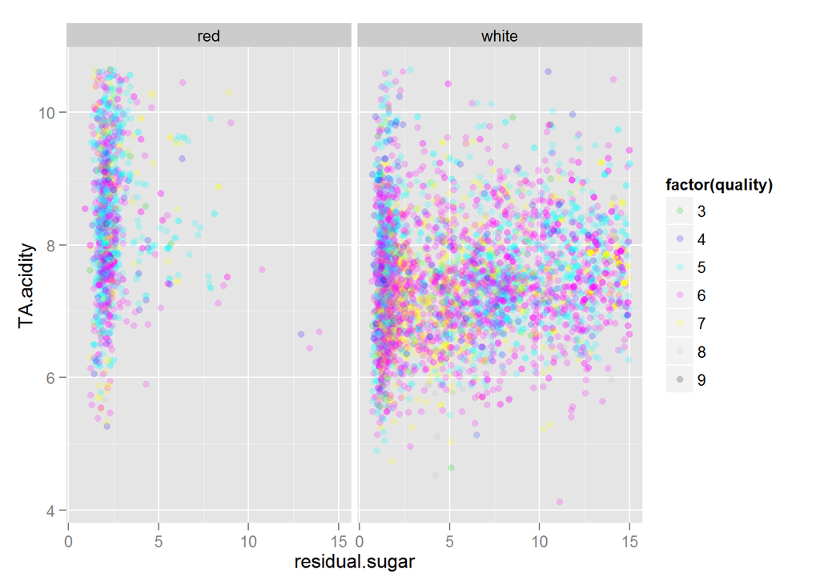

It seems that overall the quality ratings residual sugar and acidity have the same behaviour.Therefore, they do not affect the quality of both red and white wines, But looking at the correlation table below we can see that actually for high-quality ratings like 8 and 9 there is a high correlation between TA acidity and residual sugar.Which in fact, confirms my theory that in order to get a high-quality wine residual sugar and total acidity should balance each other.When it comes to other wines the relationship is weak.

|  | Q3 | Q4 | Q5 | Q6 | Q7 | Q8 | Q9 |
| --- | --- | --- | --- | --- | --- | --- | --- |
| White W.TA.Acidity | 0.19 | 0.10 | 0.05 | 0.08 | 0.22 | 0.31 | 0.93 |
| / Res.Sugar |  |  |  |  |  |  |  |
| Red W. TA.Acidity | -0.24 | -0.10 | 0.16 | 0.08 | 0.19 | 0.47 | - |
| / Res.Sugar |  |  |  |  |  |  |  |

It seems that over all the quality ratings residual sugar and acidity have the same behaviour.Therefore they do not affect the quality of both red and white wines,

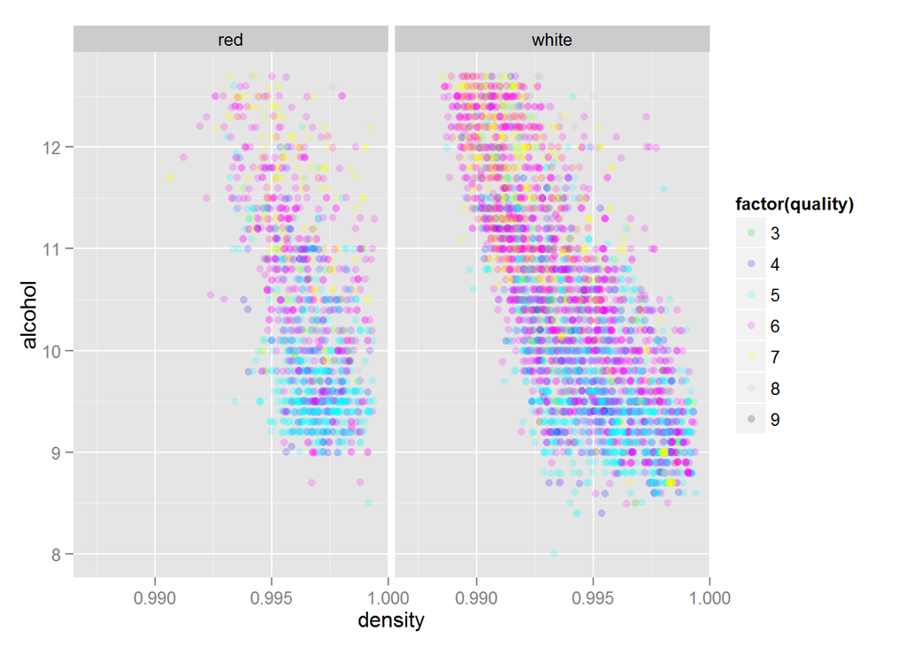

|  | Q3 | Q4 | Q5 | Q6 | Q7 | Q8 | Q9 |
| --- | --- | --- | --- | --- | --- | --- | --- |
| White W.ALcohol | -0.61 | -0.70 | -0.67 | -0.74 | -0.84 | -0.87 | -0.97 |
| / Density |  |  |  |  |  |  |  |
| Red W.Alcohol | -0.49 | -0.42 | -0.29 | -0.55 | -0.58 | -0.54 | - |
| / Density |  |  |  |  |  |  |  |

We can see that higher quality wines contain more alcohol and are less dense as I suspected. The correlation table confirms that observation byt showing high correlation values for density and acohol across all quality ratings of the wine present in teh sample.

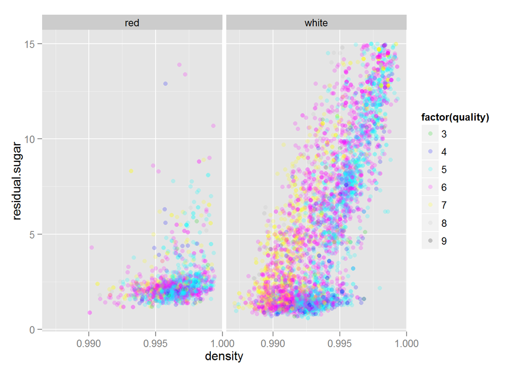

|  | Q3 | Q4 | Q5 | Q6 | Q7 | Q8 | Q9 |
| --- | --- | --- | --- | --- | --- | --- | --- |
| White W. Density | 0.70 | 0.74 | 0.89 | 0.86 | 0.82 | 0.82 | 0.95 |
| / Res.Sugar |  |  |  |  |  |  |  |
| Red W. Density | 0.20 | 0.03 | 0.45 | 0.35 | 0.33 | 0.58 | - |
| / Res.Sugar |  |  |  |  |  |  |  |

```
##
## Call:
## lm(formula = quality ~ alcohol + density + volatile.acidity,
##     data = subset(wine, color == "white"))
##
## Residuals:
##     Min      1Q  Median      3Q     Max
## -3.4087 -0.4890 -0.0361  0.4832  3.0347
##
## Coefficients:
##                   Estimate Std. Error t value Pr(>|t|)
## (Intercept)      -36.49861    6.00054  -6.083 1.27e-09 ***
## alcohol            0.39889    0.01442  27.670  < 2e-16 ***
## density           38.99189    5.92019   6.586 4.98e-11 ***
## volatile.acidity  -2.07212    0.11015 -18.811  < 2e-16 ***
## ---
## Signif. codes:  0 '***' 0.001 '**' 0.01 '*' 0.05 '.' 0.1 ' ' 1
##
## Residual standard error: 0.7688 on 4894 degrees of freedom
## Multiple R-squared:  0.2469, Adjusted R-squared:  0.2464
## F-statistic: 534.8 on 3 and 4894 DF,  p-value: < 2.2e-16
```

```
##
## Call:
## lm(formula = quality ~ alcohol + density + volatile.acidity,
##     data = subset(wine, color == "red"))
##
## Residuals:
##      Min       1Q   Median       3Q      Max
## -2.61526 -0.39782 -0.07035  0.46700  2.25079
##
## Coefficients:
##                   Estimate Std. Error t value Pr(>|t|)
## (Intercept)      -18.40654   10.29779  -1.787   0.0741 .
## alcohol            0.33321    0.01849  18.019   <2e-16 ***
## density           21.35964   10.22796   2.088   0.0369 *
## volatile.acidity  -1.36524    0.09557 -14.285   <2e-16 ***
## ---
## Signif. codes:  0 '***' 0.001 '**' 0.01 '*' 0.05 '.' 0.1 ' ' 1
##
## Residual standard error: 0.6671 on 1595 degrees of freedom
## Multiple R-squared:  0.3189, Adjusted R-squared:  0.3176
## F-statistic: 248.9 on 3 and 1595 DF,  p-value: < 2.2e-16
```

I used the variables that from my analysis seemed to be the most correlated with quality and i also separated the models by the color of the wine. The R^2 that I got were very low. Including other variables may be help to increase the accuracy of the model.

# Final Plots and Summary

### Plot One

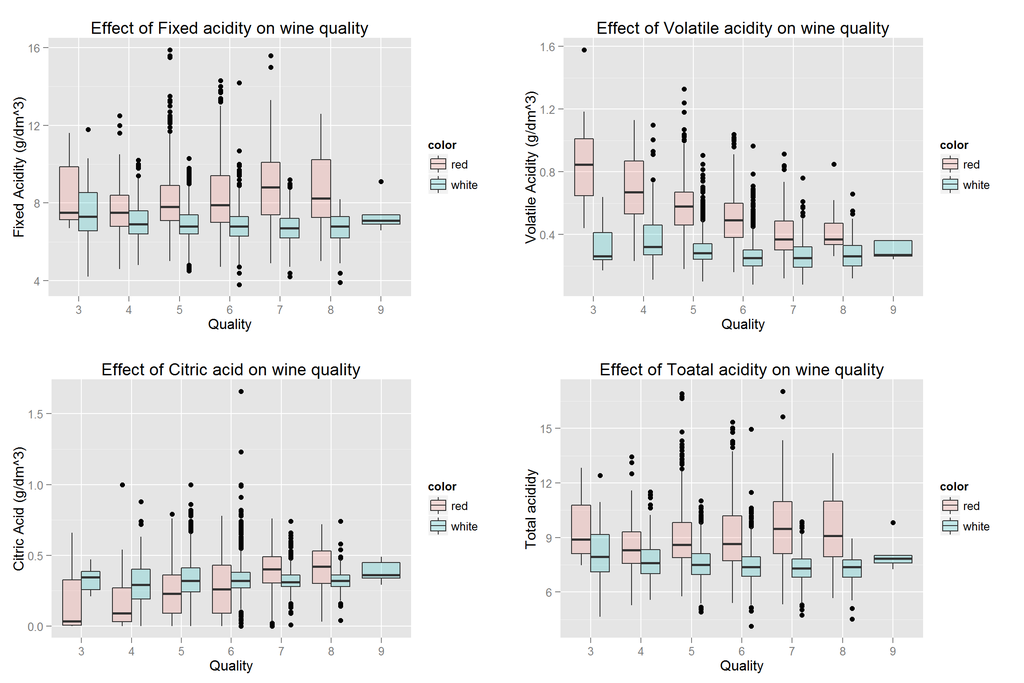

### Description One

|  | Fixed Acidity | Volatile Acidity | Citric Acid | Total Acid |
| --- | --- | --- | --- | --- |
| White W.Quality | - 0.11 | - 0.19 | - 0.01 | - 0.13 |
| Red W.Quality | 0.12 | - 0.39 | 0.22 | 0.10 |

The boxplots and the table above show the correlations among quality and acids for red and white wines. The acids that have the most effect on quality are volatile and citric acids. The interesting thing is that for red wines all the acids except volatile acid are positively correlated with quality while for white wines it’s the opposite. Fixed Acidity and total acidity doesn’t seem to have an impact on quality. Another interesting thing is that from the boxplot above it seems that volatile acidity negatively affects quality for red wines and the values in the table above confirms it.Also, the rising of citric acids in red wines positively affects quality while it does not have any effect in white wine quality.

### Plot Two

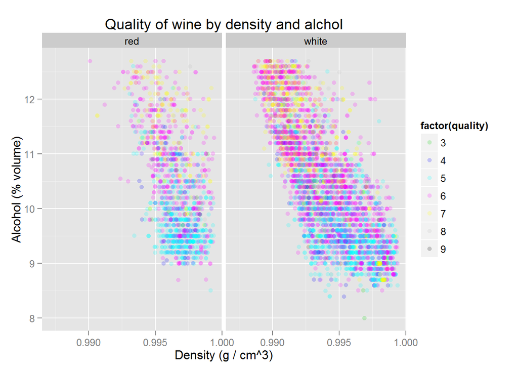